# Fórmula del binomio de Newton

## Ejemplo del Principio de Inducción: Fórmula del binomio de Newton

## Potencias de un binomio

En secundaria,y bajo el epígrafe *productos notables*, se estudian fórmulas que involucran el cuadrado y el cubo de binomios, o el producto de una suma por una diferencia.

En particular, suponemos conocidas las fórmulas del cuadrado de un binomio: \[ (a+b)^2 =a^2+2ab+b^2, \] así como la del cubo de un binomio: \[ (a+b)^3=a^3+3a^2b+3ab^2+b^3. \] Nos proponemos ahora, usando el Principio de inducción, ver como podemos extender estas fórmulas a cualquier potencia de un binomio: es la llamada **fórmula del binomio de Newton**

## Fórmula del binomio de Newton

**Proposición: Fórmula del binomio de Newton**

Sean \(a,b \in \mathbb{R}\) y sea \(n \in \mathbb{N}\), entonces: \[ (a+b)^n = \sum_{k=0}^n {n \choose k} a^{n-k}b^k \] \[ = {n \choose 0}a^n+{n \choose 1} a^{n-1} b+ {n \choose 2} a^{n-2} b^2 + \cdots + {n \choose {n-1}} ab^{n-1}+ {n \choose n} b^n \]

donde \({n \choose k}\) indica el número combinatorio definido de la forma: \[ {n \choose k} =\dfrac{n!}{(n-k)!k!} \]

## La fórmula del binomio de Newton

Para \(n=2\): \[ (a+b)^2 = a^2+2ab+b^2 \] Para \(n=3\): \[ (a+b)^3 = a^3+3a^2b+3ab^2 + b^3 \]

Para \(n=4\): \[ (a+b)^4 = a^4+4a^3b+6a^2b^2+4ab^3+b^4 \] Para \(n=5\): \[ (a+b)^5= a^5+5a^4b+10a^3b^2+10a^2b^3+5ab^4+b^5 \]

## Triángulo de Pascal

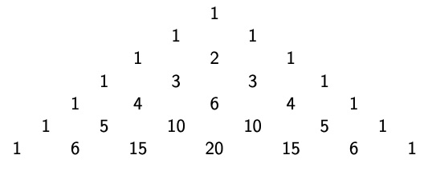

## Triángulo de Pascal

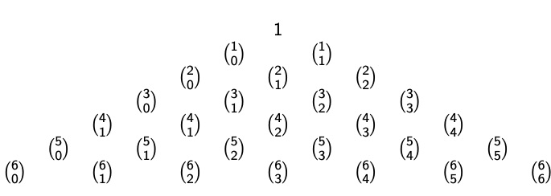

## Triángulo ¿de Pascal?

[figure not shown]

## La fórmula del binomio de Newton

Para la demostración de la fórmula del binomio es conveniente recordar la siguientes propiedades de los números combinatorios:

1. \(\displaystyle{ {n \choose k} = {n \choose {n-k}}}\)
2. \(\displaystyle{{n \choose 0} = {n \choose n} =1}\)
3. \(\displaystyle{{n \choose 1} = {n \choose {n-1}} =n}\)
4. \(\displaystyle{{n \choose k} = {{n-1} \choose {k-1}}+ {{n-1} \choose k}}\)

## La fórmula del binomio de Newton

**Demostración:**

Usaremos el principio de inducción:

1. La igualdad se cumple para \(n=1\), puesto que, en este caso, ambos miembros son iguales a \(a+b\).
2. Supongamos ahora que la igualdad es cierta hasta \(n-1\), es decir que

\[ (a+b)^{n -1} = \sum_{k=0}^{n-1} {{n-1} \choose k} a^{n-1-k}b^k \] \[ = {{n-1} \choose 0}a^{n-1}+{{n-1} \choose 1} a^{n-2} b+ {{n-2} \choose 2} a^{n-3} b^2 + \cdots \] \[ +{{n-1} \choose k} a^{n-1-k}b^k + \cdots + {{n-1} \choose {n-2}} ab^{n-2}+ {{n-1} \choose {n-1}} b^{n-1}, \]

Veamos que también es cierta para \(n\).

## La fórmula del binomio de Newton

**Demostración:**

\[ (a+b)^n = (a+b) (a+b)^{n-1} = a(a+b)^{n-1}+b(a+b)^{n-1} \] Ahora utilizamos la hipótesis de inducción para calcular \(a(a+b)^{n-1}\): \[ a(a+b)^{n-1} = {{n-1} \choose 0}a^n+{{n-1} \choose 1} a^{n-1} b+ {{n-1} \choose 2} a^{n-2} b^2 + \cdots \] \[ +{{n-1} \choose k} a^{n-k}b^k + \cdots + {{n-1} \choose {n-2}} a^2b^{n-2}+ {{n-1} \choose {n-1}} ab^{n-1}. \]

Hacemos lo mismo con \(b(a+b)^{n-1}\): \[ b(a+b)^{n-1} = {{n-1} \choose 0}a^{n-1} b+{{n-1} \choose 1} a^{n-2} b^2+ {{n-1} \choose 2} a^{n-3} b^3 + \cdots \] \[ +{{n-1} \choose {k-1}} a^{n-k}b^{k} + \cdots + {{n-1} \choose {n-2}} ab^{n-1}+ {{n-1} \choose {n-1}} b^n. \]

## La fórmula del binomio de Newton

**Demostración:**

Al sumar miembro a miembro las dos igualdades anteriores, agrupando los términos en \(a^{n-k} b^k\) y teniendo en cuenta las propiedades de los números combinatorios, resulta, por una parte, que \[ {{n-1} \choose 0}a^n = {n \choose 0}a_n \quad \text{y} \quad {{n-1} \choose {n-1}}b^n = {n \choose n}b^n \] Por otra parte, dado que \[ \left[{{n-1} \choose k} + {{n-1} \choose {k-1}} \right] a^{n-k}b^k = {n \choose k}a^{n-k}b^k, \]

queda demostrada la fórmula del binomio de Newton: \[ (a+b)^{n} = \sum_{k=0}^{n} {{n} \choose k} a^{n-k}b^k = {n \choose 0}a^n+{n \choose 1} a^{n-1} b+ {n \choose 2} a^{n-2} b^2 + \cdots + {n \choose {n-1}} ab^{n-1}+ {n \choose n} b^n \]